# Stat 202: Lecture 12 (End of Lecture 11 + Review)

Nathan VanHoudnos  
10/17/2014

### Agenda

1. Homework comments
2. Checkpoint #13 results
3. Lecture 12

### Homework comments

Question 6:

- (A) What is the IQ of a women 4 standard deviations from the mean? (5 pts)
- (E) What is the IQ of a man 4 standard deviations from the mean? (5 pts)

Was meant to be:

- (A) What is the IQ of a women 4 standard deviations above the mean? (5 pts)
- (E) What is the IQ of a man 4 standard deviations above the mean? (5 pts)

### Agenda

1. Homework comments
2. Checkpoint #13 results
3. Lecture 12

### Checkpoint #13 results

- 92% correct
- Good job!

### Agenda

1. Homework comments
2. Checkpoint #13 results
3. Lecture 12
   - Finishing up Lecture 11
   - Review

### A further example

At StatsPie, the amount of cheese used to make a typical pizza is normally distributed with a mean value of 6 oz with a variance of ¼ oz. What is the probability that a pizza will use at least 7.34 oz of cheese?

Step 1: How many standard deviations is 7.34 away from the mean? \[ \begin{aligned} P(X \ge 7.34) & = P(Z \ge z) \\ z & = \frac{7.34 - 6}{\sqrt{1/4}} = 2.68 \end{aligned} \] implying 7.34 is 2.68 standard deviations from the mean.

### Extending the 68–95–99.7 rule

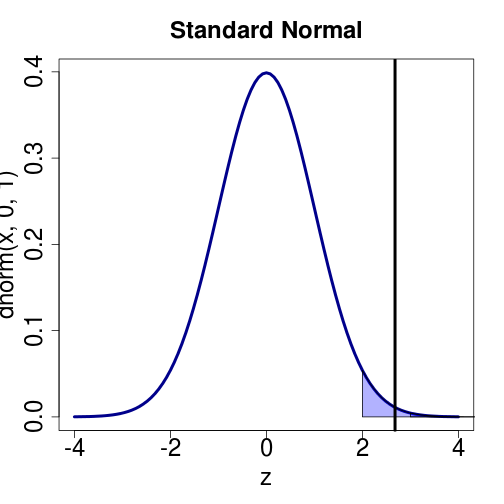

We know that \( P(Z \ge 2.68 ) \) will be somewhere between 2.5% and 0.15%.

- A famous result in calculus is that **there is no closed form formula** for the area under a normal curve.
- Use a table (or software)

### A standard normal table

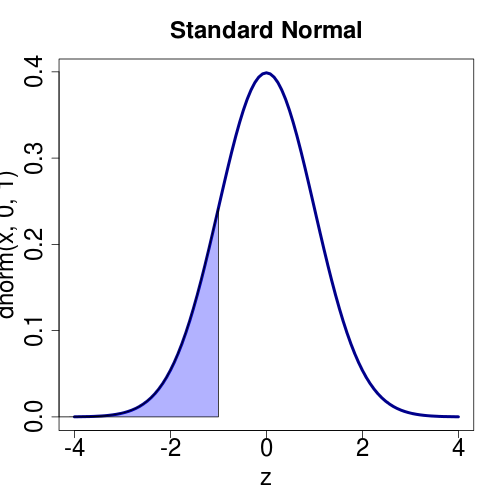

Gives the area to the left of \( z \).

To use:

1. Express your z-score as **less than**.
2. Find the **row** with the first two digits of \( z \).
3. Find the **column** with the third digit of \( z \)
4. Read off the value.

Best explained by looking at one.

### Example

Step 1:

\( P(Z \ge 2.68 ) = 1 - P(Z \le 2.68 ) \)

Step 2: \( 2.68 = 2.6 + 0.08 \) find \( 2.6 \)

| z | .00 | .01 | .02 | .03 | .04 | .05 | .06 | .07 | .08 | .09 |
| --- | --- | --- | --- | --- | --- | --- | --- | --- | --- | --- |
| 2.5 | .9938 | .9940 | .9941 | .9943 | .9945 | .9946 | .9948 | .9949 | .9951 | .9952 |
| 2.6 | .9953 | .9955 | .9956 | .9957 | .9959 | .9960 | .9961 | .9962 | .9963 | .9964 |
| 2.7 | .9965 | .9966 | .9967 | .9968 | .9969 | .9970 | .9971 | .9972 | .9973 | .9974 |

We want:

| z | .00 | .01 | .02 | .03 | .04 | .05 | .06 | .07 | .08 | .09 |
| --- | --- | --- | --- | --- | --- | --- | --- | --- | --- | --- |
| 2.6 | .9953 | .9955 | .9956 | .9957 | .9959 | .9960 | .9961 | .9962 | .9963 | .9964 |

### Example

Step 1: \( P(Z \ge 2.68 ) = 1 - P(Z \le 2.68 ) \)

Step 2: \( 2.68 = 2.6 + 0.08 \) find \( 2.6 \)

| z | .00 | .01 | .02 | .03 | .04 | .05 | .06 | .07 | .08 | .09 |
| --- | --- | --- | --- | --- | --- | --- | --- | --- | --- | --- |
| 2.6 | .9953 | .9955 | .9956 | .9957 | .9959 | .9960 | .9961 | .9962 | .9963 | .9964 |

Step 3: \( 2.68 = 2.6 + 0.08 \) find \( 0.08 \)

| z | .08 |
| --- | --- |
| 2.6 | .9963 |

Solve:

\( P(Z \ge 2.68 ) = 1 - P(Z \le 2.68 ) = 1 - .9963 = 0.0037 \)

### Pulling it together

At StatsPie, the amount of cheese used to make a typical pizza is normally distributed with a mean value of 6 oz with a variance of ¼ oz. What is the probability that a pizza will use at least 7.34 oz of cheese?

\[ \begin{aligned} P(X \ge 7.34) & = P(Z \ge 2.68 ) \\ & = 1 - P(Z \le 2.68 ) \\ & = 1 - .9963 = 0.0037 \end{aligned} \]

implying that only 0.37% of pizzas will use at least 7.34 oz of cheese.

### Using R

At StatsPie, the amount of cheese used to make a typical pizza is normally distributed with a mean value of 6 oz with a variance of ¼ oz. What is the probability that a pizza will use at least 7.34 oz of cheese?

Find the z-score:

```r
(7.34-6)/sqrt(1/4)
```

```
[1] 2.68
```

### Using R

At StatsPie, the amount of cheese used to make a typical pizza is normally distributed with a mean value of 6 oz with a variance of ¼ oz. What is the probability that a pizza will use at least 7.34 oz of cheese?

Lookup \( P(Z \le 2.68) \)

```r
pnorm( 2.68 )
```

```
[1] 0.9963
```

### Using R

At StatsPie, the amount of cheese used to make a typical pizza is normally distributed with a mean value of 6 oz with a variance of ¼ oz. What is the probability that a pizza will use at least 7.34 oz of cheese?

Find \( P(Z \ge 2.68) = 1 - (Z \le 2.68) \)

```r
1 - pnorm( 2.68 )
```

```
[1] 0.003681
```

implying that 0.37% of pizzas use at least 7.34 oz of cheese.

### Going the other way

At StatsPie, the amount of cheese used to make a typical pizza is normally distributed with a mean value of 6 oz with a variance of ¼ oz. How much cheese would the top 10% of pizzas contain?

We know that:

\[ P(X \ge x) = .1 \]

what is \( x \)?

### Going the other way

\[ \begin{aligned} P(X \ge x) & = .10 \\ & = P(\frac{X - 6}{\sqrt{1/4}} \ge \frac{x - 6}{\sqrt{1/4}}) \\ & = P(Z \ge z ) = .10 \end{aligned} \]

To find the correct \( z \) value we express it as less than:

\[ P(Z \ge z) = .1 = 1 - P(Z \le z) \]

Implying that we need to lookup

\[ P(Z \le z) = 1 - .1 = .90 \]

in our table.

### Going the other way

| z | .00 | .01 | .02 | .03 | .04 | .05 | .06 | .07 | .08 | .09 |
| --- | --- | --- | --- | --- | --- | --- | --- | --- | --- | --- |
| 1.2 | .8849 | .8869 | .8888 | .8907 | .8925 | .8944 | .8962 | .8980 | .8997 | .9015 |
| 1.3 | .9032 | .9049 | .9066 | .9082 | .9099 | .9115 | .9131 | .9147 | .9162 | .9177 |

That is somewhat unsatisfying…

- \( P(Z \le 1.28) = .8997 \) and
- \( P(Z \le 1.29) = .9015 \)

Choose \( 1.28 \) as its probability is closer to .90.

### Going the other way

We wanted: \( P(Z \le z) = 1 - .1 = .90 \)

We have: \( P(Z \le 1.28) = .8997 \).

Just go with it. Therefore: \[ \begin{aligned} P(X \ge x) & = .10 \\ & = P(\frac{X - 6}{\sqrt{1/4}} \ge \frac{x - 6}{\sqrt{1/4}}) \\ & = P(Z \ge 1.28 ) = .10 \end{aligned} \]

So solve: \( \frac{x - 6}{\sqrt{1/4}} = 1.28 \)

### Going the other way

\[ \frac{x - 6}{\sqrt{1/4}} = 1.28 \]

Implies \[ x = 6 + 1.28 \sqrt{1/4} = 6.64 \]

### Pulling it together

At StatsPie, the amount of cheese used to make a typical pizza is normally distributed with a mean value of 6 oz with a variance of ¼ oz. How much cheese would the top 10% of pizzas contain?

\[ P(X \ge x) = .1 \]

\[ x = 6 + 1.28 \sqrt{1/4} = 6.64 \]

implies that at least 6.64 oz of cheese are used to make the top 10% of pizzas.

### Using R

At StatsPie, the amount of cheese used to make a typical pizza is normally distributed with a mean value of 6 oz with a variance of ¼ oz. How much cheese would the top 10% of pizzas contain?

\[ P(X \ge x) = .1 \]

Express the z-score probability as a less than:

\[ P(Z \ge z) = 1 - P(Z \le z) = .1 \]

\( P(Z \le z) = .90 \)

### Using R

At StatsPie, the amount of cheese used to make a typical pizza is normally distributed with a mean value of 6 oz with a variance of ¼ oz. How much cheese would the top 10% of pizzas contain?

Look \( P(Z \le z) = .90 \) up in R

```r
qnorm(.90)
```

```
[1] 1.282
```

implying that the z score is \( 1.282 \).

### Using R

At StatsPie, the amount of cheese used to make a typical pizza is normally distributed with a mean value of 6 oz with a variance of ¼ oz. How much cheese would the top 10% of pizzas contain?

Convert \( z = 1.282 \) to the units of X.

```r
6 + sqrt(1/4) * 1.282
```

```
[1] 6.641
```

implying that the top 10% of pizzas use at least \( 6.64 \) of cheese.

### A further example

At StatsPie, the amount of cheese used to make a typical pizza is normally distributed with a mean value of 6 oz with a variance of ¼ oz. What is the probability of getting a pizza that has between 5.4 and 6.7 ounces of cheese?

\[ P(5.4 \le X \le 6.7) = ? \]

Draw a picture to express it in terms of “less than”:

\[ P(5.4 \le X \le 6.7) = P(X \le 6.7) - P(X \le 5.4) \]

### Picture

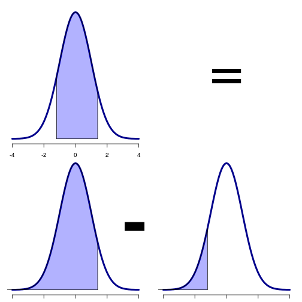

\[ \begin{aligned} P(& 5.4 \le X \le 6.7) = \\ & P(X \le 6.7) - P(X \le 5.4) \end{aligned} \]

Since you already know how to solve the “less than” problems, you can solve this problem too.

### Solution

\( P(X \le 6.7) = P(\frac{X-6}{\sqrt{1/4}} \le \frac{6.7-6}{\sqrt{1/4}}) = P(Z \le 1.4) \)

```r
pnorm(1.4)
```

```
[1] 0.9192
```

\( P(X \le 5.4) = P(\frac{X-6}{\sqrt{1/4}} \le \frac{5.4-6}{\sqrt{1/4}}) = P(Z \le -1.2) \)

```r
pnorm(-1.2)
```

```
[1] 0.1151
```

### Pulling it together

At StatsPie, the amount of cheese used to make a typical pizza is normally distributed with a mean value of 6 oz with a variance of ¼ oz. What is the probability of getting a pizza that has between 5.4 and 6.7 ounces of cheese?

\[ \begin{aligned} P(5.4 \le X \le 6.7) & = P(X \le 6.7) - P(X \le 5.4) \\ & = 0.9192 - 0.1151 \\ & = 0.8041 \end{aligned} \]

implying that 80% of pizzas contain between 5.4 and 6.7 oz of cheese.

### Normal Summary

Normal problems look something like this:

- Convert to a standard normal
- Express the probabilities in terms of less than
- Lookup either the probability or z-score in the table
- Convert back to the original distribution (if needed)

### Midterm

Let's talk about it.

### Midterm

- The high levels of performance on the checkpoints and homeowork assingments suggests that the class has already mastered certain skills.
- The goal of the midterm is to assess your knowledge. The midterm will
  - **touch briefly upon** the mastered skills,
  - **focus on** on the (presummed) unmastered skills, and
  - **stretch you** to use what you have learned in new ways.

### Some hints

Be sure to know how to:

- Interpret boxplots, scatterplots, five number summaries, and R's regression output
- Check independence of events and discrete random variables
- Calculate and interpret conditional probabilities
- Use Bayes' Rule and interpret the results
- Use a standard normal table to solve normal random variable problems